# R Notebook

First, a lesson in naming arguments:

```r
all.equal(1,2,3)
```

```
[1] TRUE
```

Huh? That’s not right. What’s going on?

```r
?all.equal
vector1 <- c(1,2,3)
vector2 <- c(6,7,8)
all.equal(1,5)
```

```
[1] "Mean relative difference: 4"
```

```r
all.equal(vector1,vector2)
```

```
[1] "Mean relative difference: 2.5"
```

```r
all.equal(vector1,vector2, 6)
```

```
[1] TRUE
```

```r
# So to make our function arguments more readable, we need to name them - or at least the potentially confusing ones:
all.equal(vector1, vector2, tolerance = 6)
```

```
[1] TRUE
```

# Now on to plotting

R’s default plotting function is easy enough to use for simple stuff:

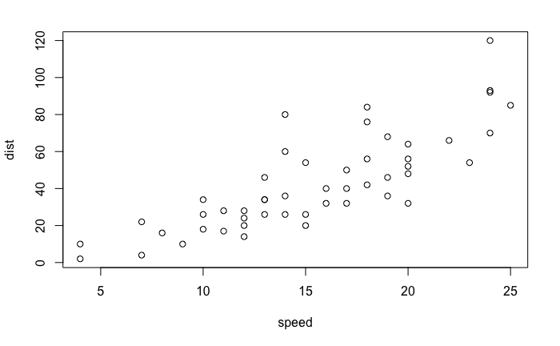

```r
plot(cars)
```

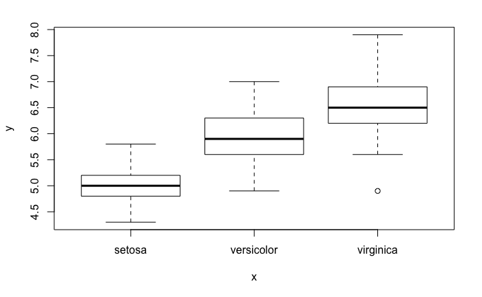

```r
plot(iris$Species, iris$Sepal.Length)
```

But it can be difficult to use when you want to tweak visual elements, or plot multiple types of information over each other, or otherwise step outside the pre-set modes. That’s where ggplot comes in.

```r
#install.packages('tidyverse')
#install.packages('dslabs')
library(tidyverse)
library(dslabs)
```

The ggplot package (stored in the tidyverse package) is based on a ‘grammar of graphics’, a philosophy about how plots can, and should be built (in layers).

ggplot(data = ) + LAYER1(MAPPING DETAILS) + LAYER2(MAPPING DETAILS) + MODIFIER(DETAILS) + MODIFIER(DETAILS)

We could spend all semester talking about ggplot (I use it probably more than any other package, and I still have a ton to learn), but my approach is that once you know the fundamentals, it’s easy enough to Google the details when you need them.

A good resource for filling in the details: RStudio’s Data Visualization with ggplot2 cheat sheet. (Talk about this a bit)

```r
#Grabbing the 'murders' dataframe, from dslabs:
data(murders)
```

Side note: It’s time to introduce the pipe - the pipe is an operator introduced by the tidyverse (magrittr specifically) that takes an object, and ‘pipes’ it in as the first argument in a function. The pipe is a good way to string multiple functions today in a much more readable way than nesting them.

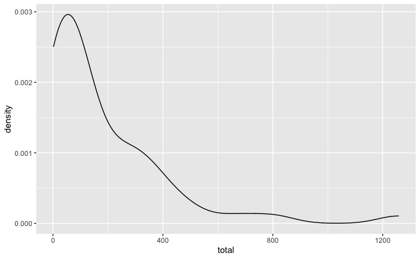

```r
murders %>%
  ggplot(aes(x=total)) +
    geom_density()
```

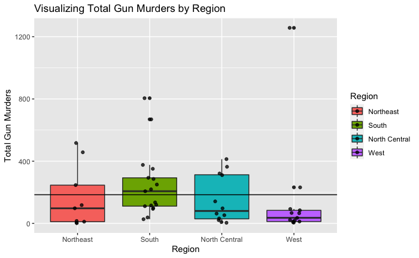

```r
murders %>%
  ggplot(aes(x=region, y = total, fill = region)) +
    geom_boxplot() +
    geom_jitter(alpha=0.75, width=0.1) +
    geom_hline(aes(yintercept = mean(total))) +
    ylab("Total Gun Murders") +
    xlab("Region") +
    labs(fill = "Region") +
    ggtitle("Visualizing Total Gun Murders by Region")
```

```r
NA
NA
```

Another example, this time using faceting:

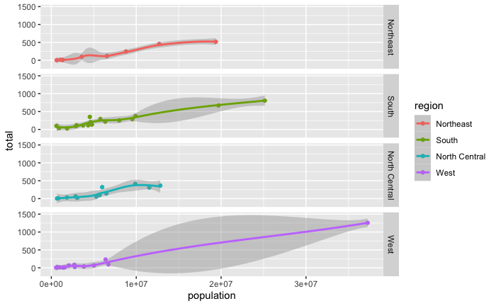

```r
murders %>%
  ggplot(aes(x=population, y=total, color=region)) +
    geom_point() +
    geom_smooth() +
    facet_grid(region~.)
```

# Now let’s cover color a little more:

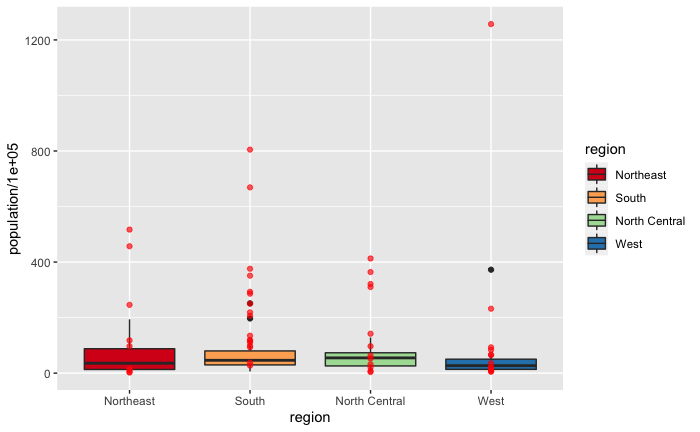

```r
# The color argument behaves differently in and out of the aes() function.
murders %>%
  ggplot() +
    geom_boxplot(aes(x=region, y=population/100000, fill=region)) +
    geom_point(aes(x=region, y=total), color = "red", alpha=0.65) +
# ggplot has some built-in color palettes that can come in handy, with the scale_fill_brewer function.
    scale_fill_brewer(palette="Spectral")
```

# Finally, let’s talk about grid arrange, and sorting:

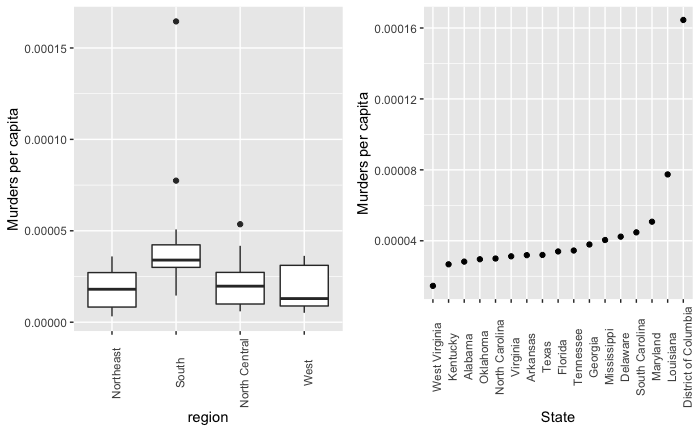

```r
install.packages("gridExtra")
library(gridExtra)
plot1 <- murders %>%
  ggplot(aes(x=region, y=total/population)) +
   geom_boxplot() +
   theme(axis.text.x=element_text(angle=90)) +
   ylab("Murders per capita")
# Let's check out those outliers in the southern region
plot2 <- murders %>%
          filter(region=="South") %>%
            ggplot(aes(x=reorder(state, total/population), y=total/population)) +
              geom_point() +
              ylab("Murders per capita") +
              xlab("State") +
              theme(axis.text.x= element_text(angle = 90))

grid.arrange(plot1, plot2, ncol=2)
```

# On to the general principles of data visualization (see other slides)